# Reproducible Research - Peer Assessment 1

József Soltész

December 13, 2015

**Initiation**

```r
library(data.table)
```

**Loading and preprocessing the data**

```r
dt<-data.table(read.csv(file = "activity.csv",header = TRUE,sep = ",",na.strings = "NA"))
dt
```

```
##        steps       date interval
##     1:    NA 2012-10-01        0
##     2:    NA 2012-10-01        5
##     3:    NA 2012-10-01       10
##     4:    NA 2012-10-01       15
##     5:    NA 2012-10-01       20
##    ---
## 17564:    NA 2012-11-30     2335
## 17565:    NA 2012-11-30     2340
## 17566:    NA 2012-11-30     2345
## 17567:    NA 2012-11-30     2350
## 17568:    NA 2012-11-30     2355
```

**What is mean total number of steps taken per day?** For this part of the assignment, you can ignore the missing values in the dataset.

1. Calculate the total number of steps taken per day

```r
SumStepsPerDay<-dt[!is.na(steps),list(sum=sum(steps)),by=date]
SumStepsPerDay
```

```
##           date   sum
##  1: 2012-10-02   126
##  2: 2012-10-03 11352
##  3: 2012-10-04 12116
##  4: 2012-10-05 13294
##  5: 2012-10-06 15420
##  6: 2012-10-07 11015
##  7: 2012-10-09 12811
##  8: 2012-10-10  9900
##  9: 2012-10-11 10304
## 10: 2012-10-12 17382
## 11: 2012-10-13 12426
## 12: 2012-10-14 15098
## 13: 2012-10-15 10139
## 14: 2012-10-16 15084
```

[output cut: 40 more lines]

2. If you do not understand the difference between a histogram and a barplot, research the difference between them. Make a histogram of the total number of steps taken each day

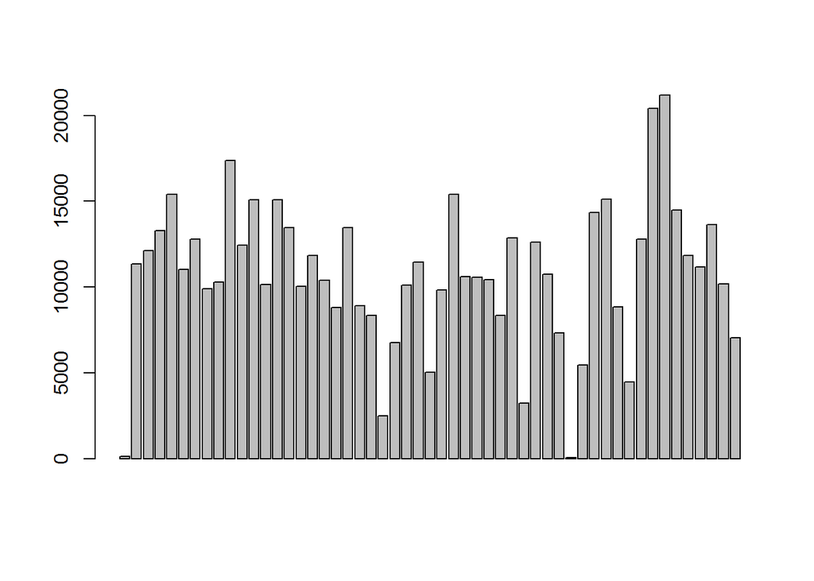

```r
barplot(SumStepsPerDay$sum)
```

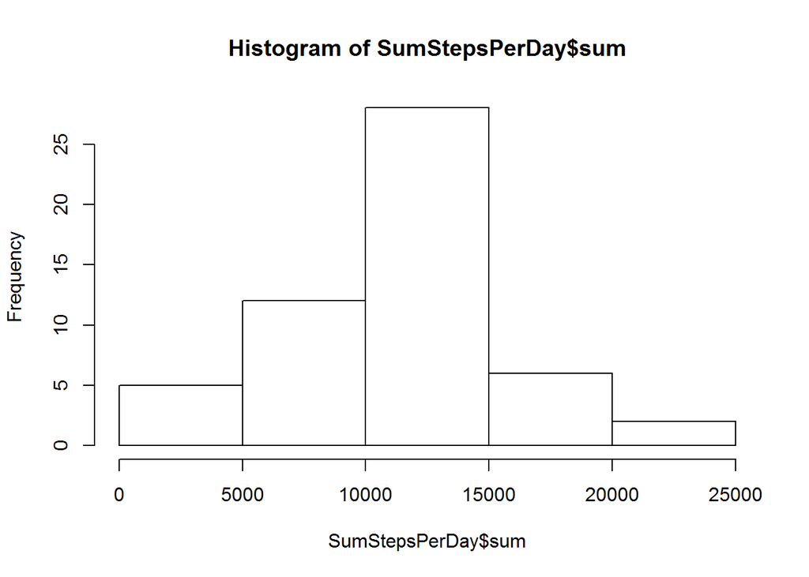

```r
hist(SumStepsPerDay$sum)
```

3. Calculate and report the mean and median of the total number of steps taken per day

```r
mean(SumStepsPerDay$sum)
```

```
## [1] 10766.19
```

```r
median(SumStepsPerDay$sum)
```

```
## [1] 10765
```

**What is the average daily activity pattern?**

[figure not shown]

```r
AvgStepsPerDay<-dt[!is.na(steps),list(sum=sum(steps)),by=date]
plot(x=AvgStepsPerDay$date,y=AvgStepsPerDay$avg, type="l")
```

2. Which 5-minute interval, on average across all the days in the dataset, contains the maximum number of steps?

```r
AvgStepsPerInterval<-dt[!is.na(steps),list(avg=mean(steps)),by=interval][order(-avg)]
AvgStepsPerInterval[1,]
```

```
##    interval      avg
## 1:      835 206.1698
```

**Imputing missing values**